# Welcome to the National Biodiversity Assessment 2025

#### Synthesis Report

The status of South Africa's ecosystems and biodiversity

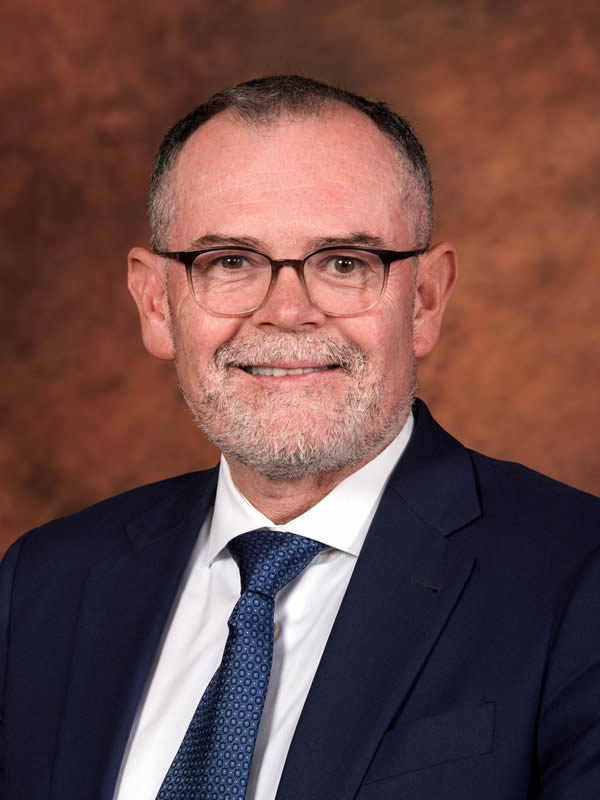

I am proud to present South Africa’s National Biodiversity Assessment 2025, a product of high scientific calibre that summarises the state of our biodiversity by drawing on a broad foundation of information compiled by over a hundred authors. This body of knowledge should be used as a basis for policy, planning and decision making regarding the wise use and conservation of our country’s biodiversity assets and the management and restoration of ecological infrastructure. The NBA is a tool not only for the environment sector, but for all sectors of government that share the responsibility for the sustainable development of our landscapes and seascapes, and is prepared as part of the South African National Biodiversity Institute (SANBI) mandate under the National Environmental Management: Biodiversity Act (Act 10 of 2004).

*Dr Dion George*

*Minister of Forestry, Fisheries and the Environment*

South Africa is a special country, with diverse cultures, remarkable geological wealth and exceptional biodiversity, much of which is unique to our nation. With this rich endowment comes the responsibility and challenge of ensuring our species and ecosystems are conserved and used sustainably to the benefit of all South Africans and future generations. This biodiversity wealth gives our people tangible benefits like food, clean water, medicine and materials; it supports agricultural and fisheries production, and helps protect us from natural hazards like floods and droughts; and it provides the basis of a vibrant tourism industry while offering natural spaces for recreational and cultural activities.

Biodiversity is central to South Africa’s national objectives of addressing poverty, inequality and unemployment, and supports increased economic growth and improved service delivery for all its citizens. Examining biodiversity in the context of social and economic change shows us that investing in ecological infrastructure is as important as investing in built infrastructure, and safeguarding the delivery of services from ecosystems can support service delivery from all spheres of government.